# Musical Genre Classifier using an Artificial Neural Network Implementation using Python-ScikitLearn and the GTZAN Dataset

Presented by : MENORCA, Matthew Gabriel R. (201806793)

# Introduction and Rationale

Musical Genre identification is an important feature for many modern music applications. Properly identifying the genre of a song creates better query results for the user, and allows a music player to properly queue songs that sound similar.

This project trained a Neural Network that can classify genres of music. These genres include and are limited **ONLY** to: **Blues, Classical, Country, Disco, Hiphop, Jazz, Metal, Pop, Reggae, and Rock.** Overall, there are **10 classifications** that the project tried to identify.

The dataset that will be used for this project is made by **Andrada Oltenau** entitled **GTZAN Dataset - Music Genre Classification**, which is available on Kaggle. This dataset is based from the popular GTZAN dataset which contains songs that were collected from 2000-2001 from personal users. The dataset can be found at https://www.kaggle.com/andradaolteanu/gtzan-dataset-music-genre-classification

Each genre from the dataset contains around 100 songs and 30 seconds each. The provided CSV file splits each song into 3 seconds providing 1000 3-second clips for each genre. **In total, there are 9990 rows in the dataset, 57 feature columns, and 1 label column.** Some of the important features in the dataset include:

1. **Chroma** : a feature of Western Music that identifies the 12 semitones.
2. **RMS (Root Mean Squared)** : determines the "loudness" of a waveform.
3. **Spectral Centroid** : determines where the center of the waveform is.
4. **Roll-Off** : determines how steep the waveform is. This is useful in determining how much compression is used on a song: particular genres of music such as Pop, and Disco typically uses a lot of compression.
5. **ZCR (Zero Crossing Rate)** : The rate at which a signal changes from the "zero" line of a waveform. Determines how quickly a song oscillates from soft to loud.
6. **Harmony** : this is where two or more different notes occur at the same time. Different harmonal properties can determine the type of scale used in a song. Dissonant harmonies for example is more frequent in Metal, and complex harmonies occur more in Jazz.
7. **Tempo (in BPM)** : determines how many downbeats occur per minute. In short, it determines the speed of the song.

# Objectives

This project aims to know if songs from the GTZAN Dataset can be classified into different genres by an Artificial Neural Network Model. It also aims to test which paramaters for the said model can achieve the highest accuracy through a series of tets. The last objective is to identify problems that were encountered during the series of tests.

# Methodology

This project trained an artificial neural network to identify genres of music into 10 different classifications. To find out the best possible architecture for the neural network, two things were considered:

- What is the ideal depth (amount of hidden layers) of the neural network?
- How many neurons should there be in each layer?

This project tried to find the relationship between **depth and accuracy**, and the relationship between **number of neurons per layer and accuracy**. In short, the project identified which combination of depth and number of neurons per layer resulted in the best accuracy score.

After identifying the depth and number of neurons to be used, the project used these parameters to create the final model to be used.

# Preparing the Dataset for Analysis

```python
import pandas as pd
path = 'features_3_sec.csv'
clips = pd.read_csv(path)
```

Remove unnecessary columns : filenames and length

```python
clips = clips.drop(['filename', 'length'], axis = 1)
clips
```

|  | chroma_stft_mean | chroma_stft_var | rms_mean | rms_var | spectral_centroid_mean | spectral_centroid_var | spectral_bandwidth_mean | spectral_bandwidth_var | rolloff_mean | rolloff_var | ... | mfcc16_var | mfcc17_mean | mfcc17_var | mfcc18_mean | mfcc18_var | mfcc19_mean | mfcc19_var | mfcc20_mean | mfcc20_var | label |
| --- | --- | --- | --- | --- | --- | --- | --- | --- | --- | --- | --- | --- | --- | --- | --- | --- | --- | --- | --- | --- | --- |
| 0 | 0.335406 | 0.091048 | 0.130405 | 0.003521 | 1773.065032 | 167541.630869 | 1972.744388 | 117335.771563 | 3714.560359 | 1.080790e+06 | ... | 39.687145 | -3.241280 | 36.488243 | 0.722209 | 38.099152 | -5.050335 | 33.618073 | -0.243027 | 43.771767 | blues |
| 1 | 0.343065 | 0.086147 | 0.112699 | 0.001450 | 1816.693777 | 90525.690866 | 2010.051501 | 65671.875673 | 3869.682242 | 6.722448e+05 | ... | 64.748276 | -6.055294 | 40.677654 | 0.159015 | 51.264091 | -2.837699 | 97.030830 | 5.784063 | 59.943081 | blues |
| 2 | 0.346815 | 0.092243 | 0.132003 | 0.004620 | 1788.539719 | 111407.437613 | 2084.565132 | 75124.921716 | 3997.639160 | 7.907127e+05 | ... | 67.336563 | -1.768610 | 28.348579 | 2.378768 | 45.717648 | -1.938424 | 53.050835 | 2.517375 | 33.105122 | blues |
| 3 | 0.363639 | 0.086856 | 0.132565 | 0.002448 | 1655.289045 | 111952.284517 | 1960.039988 | 82913.639269 | 3568.300218 | 9.216524e+05 | ... | 47.739452 | -3.841155 | 28.337118 | 1.218588 | 34.770935 | -3.580352 | 50.836224 | 3.630866 | 32.023678 | blues |
| 4 | 0.335579 | 0.088129 | 0.143289 | 0.001701 | 1630.656199 | 79667.267654 | 1948.503884 | 60204.020268 | 3469.992864 | 6.102111e+05 | ... | 30.336359 | 0.664582 | 45.880913 | 1.689446 | 51.363583 | -3.392489 | 26.738789 | 0.536961 | 29.146694 | blues |
| ... | ... | ... | ... | ... | ... | ... | ... | ... | ... | ... | ... | ... | ... | ... | ... | ... | ... | ... | ... | ... | ... |
| 9985 | 0.349126 | 0.080515 | 0.050019 | 0.000097 | 1499.083005 | 164266.886443 | 1718.707215 | 85931.574523 | 3015.559458 | 8.479527e+05 | ... | 42.485981 | -9.094270 | 38.326839 | -4.246976 | 31.049839 | -5.625813 | 48.804092 | 1.818823 | 38.966969 | rock |
| 9986 | 0.372564 | 0.082626 | 0.057897 | 0.000088 | 1847.965128 | 281054.935973 | 1906.468492 | 99727.037054 | 3746.694524 | 1.170890e+06 | ... | 32.415203 | -12.375726 | 66.418587 | -3.081278 | 54.414265 | -11.960546 | 63.452255 | 0.428857 | 18.697033 | rock |
| 9987 | 0.347481 | 0.089019 | 0.052403 | 0.000701 | 1346.157659 | 662956.246325 | 1561.859087 | 138762.841945 | 2442.362154 | 2.602871e+06 | ... | 78.228149 | -2.524483 | 21.778994 | 4.809936 | 25.980829 | 1.775686 | 48.582378 | -0.299545 | 41.586990 | rock |
| 9988 | 0.387527 | 0.084815 | 0.066430 | 0.000320 | 2084.515327 | 203891.039161 | 2018.366254 | 22860.992562 | 4313.266226 | 4.968878e+05 | ... | 28.323744 | -5.363541 | 17.209942 | 6.462601 | 21.442928 | 2.354765 | 24.843613 | 0.675824 | 12.787750 | rock |
| 9989 | 0.369293 | 0.086759 | 0.050524 | 0.000067 | 1634.330126 | 411429.169769 | 1867.422378 | 119722.211518 | 3462.042142 | 1.517016e+06 | ... | 38.801735 | -11.598399 | 58.983097 | -0.178517 | 55.761299 | -6.903252 | 39.485901 | -3.412534 | 31.727489 | rock |

9990 rows × 58 columns

Separate the label column from the dataset

```python
clips_data = clips.drop(['label'], axis = 1)
```

Extract the class labels column and assign it to a new dataframe

```python
clips_class = clips.filter(['label'])
```

Create a separate training and testing set. The `train_test_split` function automatically does this.

```python
from sklearn.model_selection import train_test_split

datasets = train_test_split(clips_data, clips_class)
train_data, test_data, train_labels, test_labels = datasets
```

Before the model can be trained, the data must be standardized first. This is due to the fact that the features in dataset have varying units and ranges. Standardizing the dataset prevents some features from overshadowing the others. The `ravel` function converts the data into a contigious 1D array that the classifier can use.

```python
from sklearn.preprocessing import StandardScaler

#ReLu
scaler = StandardScaler()

train_data = scaler.fit_transform(train_data)
test_data = scaler.transform(test_data)

test_labels = test_labels.to_numpy()
train_labels = train_labels.to_numpy()

train_labels = train_labels.ravel()
test_labels = test_labels.ravel()
```

# Analyis Part 1

For the following, the MLPClassifier module of sklearn was used to model the neural network. The activation function used for this classifier was the rectified linear unit or ReLu. By default, the solver for weight optimization is "ADAM", which is based on a version of Stochastic Gradient Descent. According to the documentation of the module, this seems to be the best optimizer for large datasets. All of the trials will use a maximum iteration of 1000, and a learning rate of 0.001

## Trial 1

For the first trial of the analysis, a single hidden layer was used with an increasing number of neurons per layer. The goal is the find out how increasing the number of neurons per layer affects the accuracy score of the model.

```python
from sklearn.neural_network import MLPClassifier
from sklearn.metrics import accuracy_score
accuracy_scores_1layer = []
hidden_layers_1layer = []

for i in range(1, 41):
    #Create a classifier
    mlp = MLPClassifier(hidden_layer_sizes=(i*10), max_iter=1000, activation='relu', learning_rate_init=0.001)
    #Fit the training data to the model
    mlp.fit(train_data, train_labels)
    predictions = mlp.predict(test_data)
    accuracy_scores_1layer.append(accuracy_score(test_labels, predictions))
    hidden_layers_1layer.append(i*10)
```

Plot the number of neurons per layer against the accuracy score.

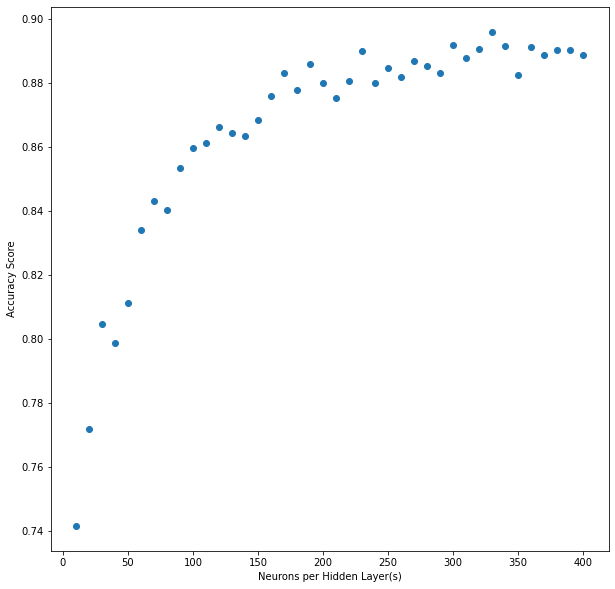

```python
from matplotlib import pyplot as plt
plt.figure(figsize=(10,10))
plt.scatter(hidden_layers_1layer, accuracy_scores_1layer)
plt.xlabel('Neurons per Hidden Layer(s)')
plt.ylabel('Accuracy Score')
```

```python
print(max(accuracy_scores_1layer))
```

```
0.8959167333867094
```

Using a single layer, a maximum accuracy of 89.59% was achieved. As can be observed from the scatter plot, increasing the number of neurons per layer increases the accuracy of the model in a fasion similar to a logistic function.

# Trial 2

For the second trial of the analysis, two hidden layers were used with an increasing number of neurons per layer. The goal is the find out how increasing the number of neurons per layer affects the accuracy score of the model.

```python
from sklearn.neural_network import MLPClassifier
from sklearn.metrics import accuracy_score
accuracy_scores_2layer = []
hidden_layers_2layer = []

for i in range(1, 41):
    #Create a classifier
    mlp = MLPClassifier(hidden_layer_sizes=(i*10, i*10), max_iter=1000, activation='relu', learning_rate_init=0.001)
    #Fit the training data to the model
    mlp.fit(train_data, train_labels)
    predictions = mlp.predict(test_data)
    accuracy_scores_2layer.append(accuracy_score(test_labels, predictions))
    hidden_layers_2layer.append(i*10)
```

Plot the number of neurons per layer against the accuracy score.

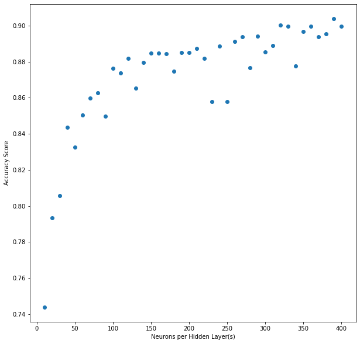

```python
from matplotlib import pyplot as plt
plt.figure(figsize=(10,10))
plt.scatter(hidden_layers_2layer, accuracy_scores_2layer)
plt.xlabel('Neurons per Hidden Layer(s)')
plt.ylabel('Accuracy Score')
```

```python
print(max(accuracy_scores_2layer))
```

```
0.9039231385108086
```

Using two hidden layers, a maximum accuracy of 90.39% was achieved. Similar results can be observved that increasing the number of neurons per layer increases the accuracy but stabilizes at a certain point.

# Trial 2.2

This trial tries to see if there would be any changes to the accuracy if a varying combination of hidden layer pairs were used.

```python
# Part 1 - Run1: neurons = 10
from sklearn.neural_network import MLPClassifier
from sklearn.metrics import accuracy_score
accuracy_scores_z = []
hidden_layers_x = []
hidden_layers_y = []

for i in range(1, 21):
    for j in range(1, 21):
        mlp = MLPClassifier(hidden_layer_sizes=(i*10, j*10), max_iter=1000, activation='relu', learning_rate_init=0.001)
        mlp.fit(train_data, train_labels)
        predictions = mlp.predict(test_data)
        hidden_layers_x.append(i*10)
        hidden_layers_y.append(j*10)
        accuracy_scores_z.append(accuracy_score(test_labels, predictions))
```

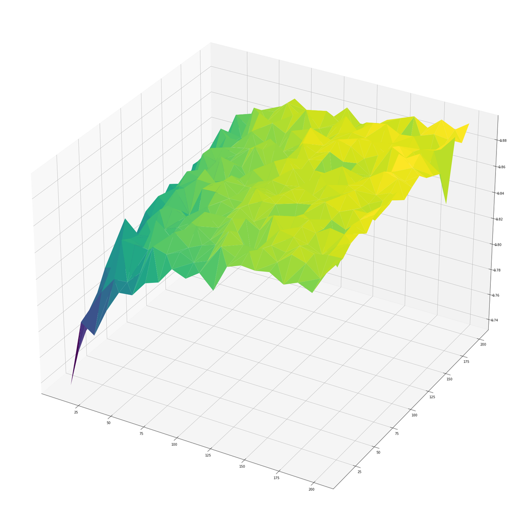

```python
from matplotlib import pyplot as plt

plt.figure(figsize=(30,30))
ax = plt.axes(projection='3d')
map = ax.plot_trisurf(hidden_layers_x, hidden_layers_y, accuracy_scores_z, cmap='viridis', linewidth=0.5)
plt.show()
```

The **x-axis** represents the first hidden layer, the **y-axis** represents the second hidden layer. The **z-axis** represents the accuracy score. The higher the peak, the higher the accuracy score.

```python
print(max(accuracy_scores_z))
```

```
0.8951160928742994
```

As can be observed from the graph above, the peak accuracy(89.51%) is actually lower than that of using two layers with the same sizes. The same results can still be observed that by increasing the number of neurons, the accuracy increases. However, this method of testing will only be done for this trial due to the limited capabilities of the machine running these algorithms.

# Trial 3

For the third trial of the analysis, three hidden layers were used with an increasing number of neurons per layer. The goal is the find out how increasing the number of neurons per layer affects the accuracy score of the model.

```python
from sklearn.neural_network import MLPClassifier
from sklearn.metrics import accuracy_score
accuracy_scores_3layer = []
hidden_layers_3layer = []

for i in range(1, 41):
    mlp = MLPClassifier(hidden_layer_sizes=(i*10, i*10, i*10), max_iter=1000, activation='relu', learning_rate_init=0.001)
    mlp.fit(train_data, train_labels)
    predictions = mlp.predict(test_data)
    hidden_layers_3layer.append(i*10)
    accuracy_scores_3layer.append(accuracy_score(test_labels, predictions))
```

Plot the number of neurons per layer against the accuracy score.

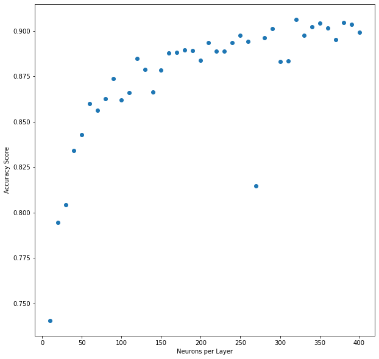

```python
from matplotlib import pyplot as plt
plt.figure(figsize=(10,10))
plt.scatter(hidden_layers_3layer, accuracy_scores_3layer)
plt.xlabel('Neurons per Layer')
plt.ylabel('Accuracy Score')
```

```python
print(max(accuracy_scores_3layer))
```

```
0.9063250600480385
```

Using three hidden layers, a maximum accuracy of 90.63% was achieved. Similar results can be observved that increasing the number of neurons per layer increases the accuracy but stabilizes at a certain point.

# Trial 4

For the fourth trial of the analysis, four hidden layers were used with an increasing number of neurons per layer. The goal is the find out how increasing the number of neurons per layer affects the accuracy score of the model. Since it is already obvious at this point that a huge number of neurons increases the accuracy, the increments were changed to 20 so that the machine can still run the training at a reasonable amount of time.

```python
from sklearn.neural_network import MLPClassifier
from sklearn.metrics import accuracy_score
accuracy_scores_4layer = []
hidden_layers_4layer = []

for i in range(5, 21):
    mlp = MLPClassifier(hidden_layer_sizes=(i*20, i*20, i*20, i*20), max_iter=1000, activation='relu', learning_rate_init=0.001)
    mlp.fit(train_data, train_labels)
    predictions = mlp.predict(test_data)
    hidden_layers_4layer.append(i*20)
    accuracy_scores_4layer.append(accuracy_score(test_labels, predictions))
```

Plot the number of neurons per layer against the accuracy score.

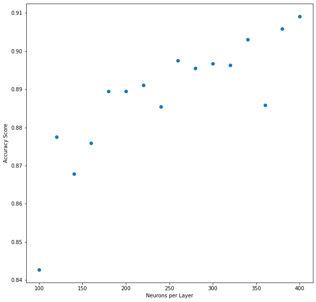

```python
from matplotlib import pyplot as plt
plt.figure(figsize=(10,10))
plt.scatter(hidden_layers_4layer, accuracy_scores_4layer)
plt.xlabel('Neurons per Layer')
plt.ylabel('Accuracy Score')
```

```python
print(max(accuracy_scores_4layer))
```

```
0.9091273018414732
```

Using four hidden layers, a maximum accuracy of 90.91% was achieved. Similar results can be observed that increasing the number of neurons per layer increases the accuracy but stabilizes at a certain point.

# Trial 5

For the fifth trial of the analysis, five hidden layers were used with an increasing number of neurons per layer. The goal is the find out how increasing the number of neurons per layer affects the accuracy score of the model.

```python
from sklearn.neural_network import MLPClassifier
from sklearn.metrics import accuracy_score
accuracy_scores_5layer = []
hidden_layers_5layer = []

for i in range(5, 21):
    mlp = MLPClassifier(hidden_layer_sizes=(i*20, i*20, i*20, i*20, i*20), max_iter=1000, activation='relu', learning_rate_init=0.001)
    mlp.fit(train_data, train_labels)
    predictions = mlp.predict(test_data)
    hidden_layers_5layer.append(i*20)
    accuracy_scores_5layer.append(accuracy_score(test_labels, predictions))
```

Plot the number of neurons per layer against the accuracy score.

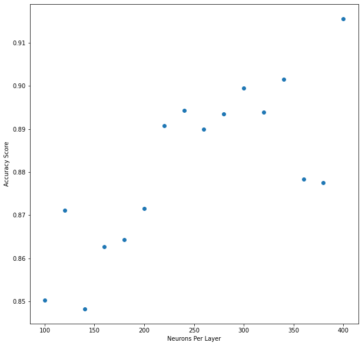

```python
from matplotlib import pyplot as plt
plt.figure(figsize=(10,10))
plt.scatter(hidden_layers_5layer, accuracy_scores_5layer)
plt.xlabel('Neurons Per Layer')
plt.ylabel('Accuracy Score')
```

```python
print(max(accuracy_scores_5layer))
```

```
0.9155324259407526
```

Using five hidden layers, a maximum accuracy of 91.55% was achieved. Similar results can be observed that increasing the number of neurons per layer increases the accuracy but stabilizes at a certain point.

# Trial 6

```python
from sklearn.neural_network import MLPClassifier
from sklearn.metrics import accuracy_score
accuracy_scores_6layer = []
hidden_layers_6layer = []

for i in range(5, 21):
    mlp = MLPClassifier(hidden_layer_sizes=(i*20, i*20, i*20, i*20, i*20, i*20), max_iter=1000, activation='relu', learning_rate_init=0.001)
    mlp.fit(train_data, train_labels)
    predictions = mlp.predict(test_data)
    hidden_layers_6layer.append(i*20)
    accuracy_scores_6layer.append(accuracy_score(test_labels, predictions))
```

Plot the number of neurons per layer against the accuracy score.

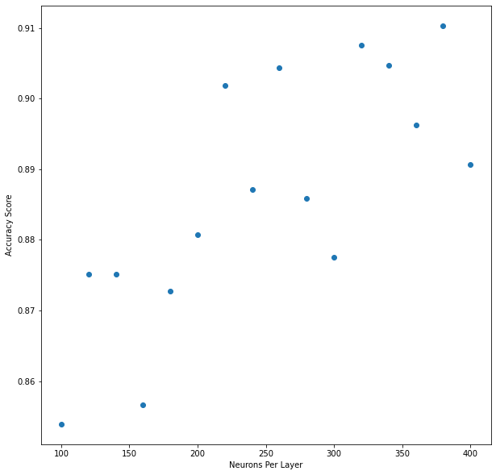

```python
from matplotlib import pyplot as plt
plt.figure(figsize=(10,10))
plt.scatter(hidden_layers_6layer, accuracy_scores_6layer)
plt.xlabel('Neurons Per Layer')
plt.ylabel('Accuracy Score')
```

```python
print(max(accuracy_scores_6layer))
```

```
0.910328262610088
```

Using six hidden layers, a maximum accuracy of 91.03% was achieved. Similar results can be observed that increasing the number of neurons per layer increases the accuracy but stabilizes at a certain point.

# Trial 7

```python
from sklearn.neural_network import MLPClassifier
from sklearn.metrics import accuracy_score
accuracy_scores_7layer = []
hidden_layers_7layer = []

for i in range(5, 21):
    mlp = MLPClassifier(hidden_layer_sizes=(i*20, i*20, i*20, i*20, i*20, i*20, i*20), max_iter=1000, activation='relu', learning_rate_init=0.001)
    mlp.fit(train_data, train_labels)
    predictions = mlp.predict(test_data)
    hidden_layers_7layer.append(i*20)
    accuracy_scores_7layer.append(accuracy_score(test_labels, predictions))
```

Plot the number of neurons per layer against the accuracy score.

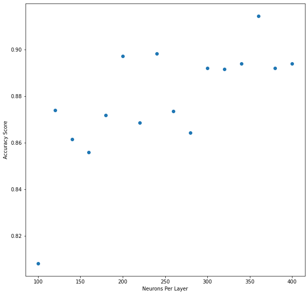

```python
from matplotlib import pyplot as plt
plt.figure(figsize=(10,10))
plt.scatter(hidden_layers_7layer, accuracy_scores_7layer)
plt.xlabel('Neurons Per Layer')
plt.ylabel('Accuracy Score')
```

```python
print(max(accuracy_scores_7layer))
```

```
0.9143314651721377
```

# Analysis of Trials

Based from the results of these trials, it is fair to say that increasing the amount of neurons per layer significantly increases the accuracy of the test scores, plateuing at around 200 neurons above. However, there are no significant differences in changing the number of hidden layers during the trials. The accuracies only range from around 89% to 91%. Therefore, it might not be conclusive to say that increasing the number of layers result in greater accuracy.

# Model Prototype

Based from previous trials, it's not really conclusive to say that deeper means better. So in line with this, an arbitrary depth of 3 was just chosen with 350 neurons, to represent a prototype.

```python
from sklearn.neural_network import MLPClassifier
from sklearn.metrics import accuracy_score

n = 350

mlp = MLPClassifier(hidden_layer_sizes=(n, n, n), max_iter=1000, activation='relu', learning_rate_init=0.001)
mlp.fit(train_data, train_labels)
predictions = mlp.predict(test_data)
```

Use the classification report function of sklearn to create the graph:

```python
from sklearn.metrics import classification_report,confusion_matrix

print(classification_report(test_labels,predictions))
```

```
              precision    recall  f1-score   support

       blues       0.89      0.92      0.90       253
   classical       0.92      0.97      0.94       230
     country       0.84      0.86      0.85       243
       disco       0.90      0.90      0.90       269
      hiphop       0.93      0.91      0.92       257
        jazz       0.91      0.88      0.90       243
       metal       0.91      0.96      0.94       241
         pop       0.92      0.88      0.90       261
      reggae       0.92      0.93      0.92       262
        rock       0.88      0.83      0.85       239

    accuracy                           0.90      2498
   macro avg       0.90      0.90      0.90      2498
weighted avg       0.90      0.90      0.90      2498
```

Use the seaborn module to create a heat map / confusion matrix.

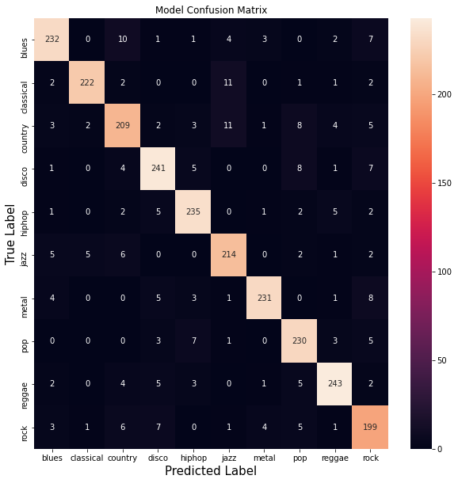

```python
from matplotlib import pyplot as plt
import seaborn as sns

cf_labels = ['blues', 'classical', 'country', 'disco', 'hiphop', 'jazz', 'metal', 'pop', 'reggae', 'rock']
cf_matrix = confusion_matrix(predictions, test_labels)

fig, ax = plt.subplots(figsize=(10,10))

map = sns.heatmap(cf_matrix, annot=True, ax=ax, fmt='g', xticklabels=cf_labels, yticklabels=cf_labels)
plt.xlabel('Predicted Label', fontsize = 15)
plt.ylabel('True Label', fontsize = 15)
plt.title('Model Confusion Matrix')

plt.show()
```

# Conclusions

As can be seen from the confusion matrix, the results are pretty decent but not accurate enough. This prototype only has an accuracy of 90%. From the classification report, the maximum f-1 score achieved was 94%, while the lowest is 85%. Based from this, classical and metal music might be the most sonically distinct among the genres while rock is the most sonically diverse. This means that the model is confident with identifying classical and metal the most, and least confident with identifying rock music.

From the trial runs performed, it was observed that it was indeed possible to classify musical genres using an artificial neural network, but only up to an accuracy of around 91%.

Based from these trials, the accuracy always seems to stabilize and plateu at around 91% accuracy, even if various depths and neurons were used. This might be an indication that some of the data were poorly labeled. Note that originally, the GTZAN dataset has around 1,000 songs but the author of the modified dataset split the songs into 3-second clips while retaining their original labels to result in a larger dataset. It might be possible that some context was lost during the trimming of the songs. Since genre is not an exact label for music, some songs might be influenced by other genres different from their labels.

Based on this, a better implementation might be to rate the songs based on how much they sound like a specific genre, instead of straight-up classifying them into a specific genre. For example, it might rate a certain song to be 90% rock, and 10% pop and that might be a better metric that faithfully represents what is needed for a real application. Nonetheless, it might be interesting to see how well this model will perform on other datasets with better labels and context-retained samples.